# ACP sur la production d’électricité en France

# informations sur les données

```r
# Il se situe dans info_acp.txt print ici
information <- readLines("info_acp.txt")
cat(information, sep = "\n")
```

```
## Data for ACP
## individuals: year
## population: last 10 years
## indicators: energy consumption
##
##
## Source: https://www.rte-france.com/eco2mix/telecharger-les-indicateurs
## Columns:
## production-tot: total production in TWh
## nuclear: nuclear production in TWh
## coal: coal production in TWh
## oil: oil production in TWh
## gas: gas production in TWh
## hydro: hydro production in TWh
## wind: wind production in TWh
## solar: solar production in TWh
## bio: bio production in TWh
## consumption-tot: total consumption in TWh
```

# Charger les données

```r
library(FactoMineR)
# read.table() permet de lire un fichier texte
# header = TRUE permet de dire que la premi`ere ligne du fichier contient les noms des variables
energy <- read.table("data_acp.csv", header = TRUE, sep = ",")
# changer l'index des lignes par la première colonne
rownames(energy) <- energy[, 1]
# supprimer la première colonne
energy <- energy[, -1]
energy
```

```
##      production.tot nuclear coal oil gas hydro wind solar bio consumption.tot
## 2012            541     404   17   6  24    63   14     4   5             489
## 2013            550     403   19   3  19    75   15     4   7             494
## 2014            540     415    8   3  14    68   17     5   7             465
## 2015            546     416    8   3  22    59   21     7   7             476
## 2016            531     383    7   2  35    64   20     8   8             483
## 2017            529     379    9   2  41    53   24     9   9             482
## 2018            548     393    5   1  31    68   28    10   9             478
## 2019            537     379    1   2  38    60   33    12   9             473
## 2020            497     335    1   0  34    65   39    12   9             488
```

# ACP

```r
# graph = FALSE permet de ne pas afficher les graphiques
# scale.unit = TRUE permet de centrer et réduire les variables
# On crée l'objet acp
acp <- PCA(energy, graph = FALSE, scale.unit = TRUE)
summary(acp)
```

```
##
## Call:
## PCA(X = energy, scale.unit = TRUE, graph = FALSE)
##
##
## Eigenvalues
##                        Dim.1   Dim.2   Dim.3   Dim.4   Dim.5   Dim.6   Dim.7   Dim.8
## Variance               6.173   1.620   1.185   0.638   0.229   0.111   0.044   0.001
## % of var.             61.734  16.197  11.846   6.375   2.286   1.111   0.445   0.006
## Cumulative % of var.  61.734  77.931  89.777  96.152  98.438  99.549  99.994 100.000
##
## Individuals
##                     Dist    Dim.1    ctr   cos2    Dim.2    ctr   cos2    Dim.3    ctr   cos2
## 2012            |  4.077 |  3.526 22.371  0.748 |  1.097  8.250  0.072 | -1.471 20.291  0.130 |
## 2013            |  3.873 |  3.074 17.003  0.630 |  1.747 20.944  0.203 |  1.249 14.637  0.104 |
## 2014            |  3.189 |  2.021  7.353  0.402 | -1.744 20.870  0.299 |  1.191 13.311  0.140 |
## 2015            |  1.998 |  1.226  2.707  0.377 | -1.286 11.349  0.414 | -0.447  1.875  0.050 |
## 2016            |  1.049 | -0.488  0.429  0.216 |  0.355  0.863  0.114 | -0.234  0.515  0.050 |
## 2017            |  2.620 | -1.572  4.446  0.360 | -0.043  0.013  0.000 | -1.826 31.261  0.486 |
## 2018            |  2.059 | -1.049  1.981  0.260 | -0.731  3.667  0.126 |  1.133 12.046  0.303 |
## 2019            |  2.920 | -2.478 11.054  0.721 | -1.243 10.593  0.181 | -0.329  1.017  0.013 |
## 2020            |  4.846 | -4.260 32.657  0.773 |  1.849 23.451  0.146 |  0.734  5.047  0.023 |
##
## Variables
##                    Dim.1    ctr   cos2    Dim.2    ctr   cos2    Dim.3    ctr   cos2
## production.tot  |  0.723  8.472  0.523 | -0.423 11.027  0.179 |  0.061  0.312  0.004 |
## nuclear         |  0.856 11.875  0.733 | -0.486 14.611  0.237 |  0.010  0.008  0.000 |
## coal            |  0.874 12.387  0.765 |  0.396  9.698  0.157 | -0.127  1.367  0.016 |
## oil             |  0.854 11.801  0.729 |  0.008  0.004  0.000 | -0.422 15.008  0.178 |
## gas             | -0.792 10.149  0.627 |  0.104  0.668  0.011 | -0.470 18.618  0.221 |
## hydro           |  0.384  2.391  0.148 |  0.323  6.440  0.104 |  0.841 59.695  0.707 |
## wind            | -0.947 14.533  0.897 |  0.017  0.018  0.000 |  0.128  1.373  0.016 |
## solar           | -0.971 15.283  0.944 | -0.116  0.832  0.013 | -0.006  0.003  0.000 |
## bio             | -0.893 12.921  0.798 | -0.144  1.288  0.021 |  0.165  2.311  0.027 |
## consumption.tot |  0.108  0.187  0.012 |  0.947 55.414  0.898 | -0.124  1.305  0.015 |
```

# Représentation des variables

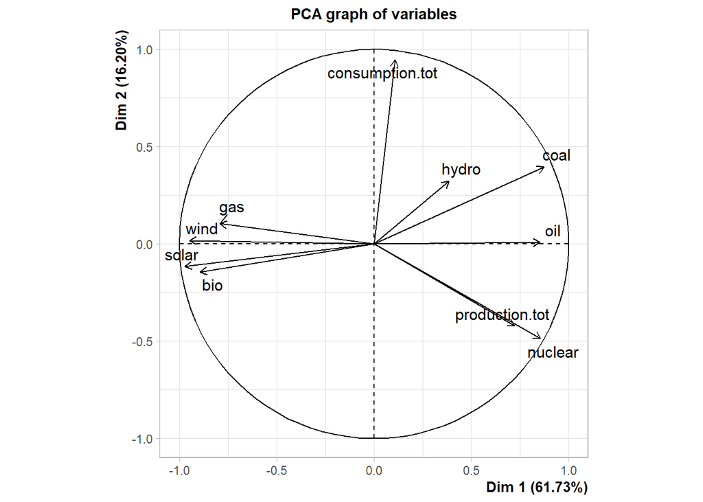

```r
# Représentation des variables avec annotation des années
plot(acp, choix = "var")
```

# Représentation des individus

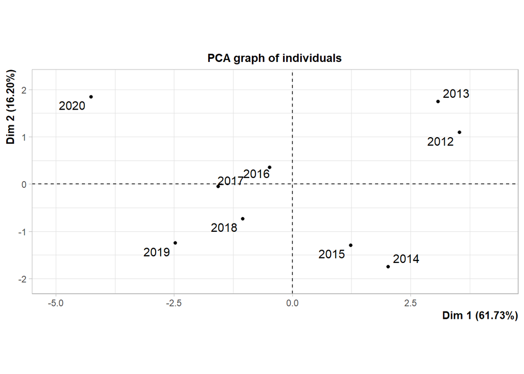

```r
# plot() permet de représenter les individus
# choix = "ind" permet de représenter les individus
# Représentation des individus avec annotation des années
plot(acp, choix = "ind")
```

# Analyse

> Cette analyse porte sur la production d’électricité en France pour les années 2012 à 2020, ainsi que sur les composantes principales résultant de l’analyse en composantes principales (PCA). Voici une analyse approfondie des principales observations :

## 1. Variance expliquée par les composantes principales :

> Les deux premières composantes principales expliquent ensemble 77.931% de la variance, ce qui est considéré comme un pourcentage élevé. Cela suggère que ces deux dimensions capturent une grande partie de l’information contenue dans les données.

## 2. Corrélations entre les variables :

> - La production totale d’électricité est fortement corrélée à la production d’énergie nucléaire.
> - Les énergies renouvelables (solaire, éolien, bioénergie) et le gaz sont corrélés entre eux, formant un groupe distinct.

## 3. Analyse des dimensions principales :

### Dimension 1 :

> - Corrélée positivement avec le pétrole, le charbon, le nucléaire, et la production totale (énergies fossiles et nucléaire).
> - Corrélée négativement avec les énergies renouvelables et le gaz.

### Dimension 2 :

> - Corrélée positivement avec la consommation totale.
> - Légèrement corrélée négativement avec la production totale et le nucléaire.

## 4. Analyse des individus (années) :

> - La dimension 1 peut être interprétée comme une timeline, les années les plus récentes ayant des valeurs négatives et les plus anciennes ayant des valeurs positives.

## 5. Observations spécifiques :

> - La faible représentation et contribution de la variable hydroélectricité s’explique par l’exploitation déjà maximale de son potentiel en France (peu de variation d’une année sur l’autre).
> - Les années récentes montrent une tendance à la baisse de la production totale d’électricité, avec une augmentation des énergies renouvelables.

## 6. Interprétation générale :

> - La France semble dépendante des énergies nucléaire et fossile, bien que les énergies renouvelables gagnent en importance.
> - La consommation totale joue un rôle important dans la deuxième dimension et n’est corrélée à aucune autre variable, suggérant qu’elle est indépendante des capacités de production.

## Conclusion :

> Cette analyse suggère une évolution vers des sources d’énergie plus durables, bien que la France soit toujours fortement influencée par les énergies nucléaire et fossile. Les données indiquent également des variations significatives au fil du temps, avec des groupes d’années montrant des tendances communes.